# Probability: **Probability Density Functions**

Most probabilities in statistics are calculated from **probability density functions** (PDFs). A PDF is a mathematical function that describes the probability with which a random variable is expected to adopt specific values.

The three types of random variables we will consider are: uniform, normal and $\chi^2$ (Fig.7.1). The distributions in Fig.7.1 are called **probability density functions** (PDF). The most important characteristic of a PDF is that the total probability is one:

$$\int_{-\infty}^{+\infty} f(x) = 1$$

This is equivalent to:

$$P(-\infty < x < +\infty) = 1$$

where $f(x)$ is the PDF. In other words, the probability that $x$ has a value between $-\infty$ and $+\infty$ is 1 (or 100%).

## Probability calculations in Python

Let's first import the packages we'll need for this notebook:

```python
import numpy as np
from scipy import stats
from matplotlib import pyplot as plt
```

The PDFs for uniform, normal and $\chi^2$ random variables can be generated as follows:

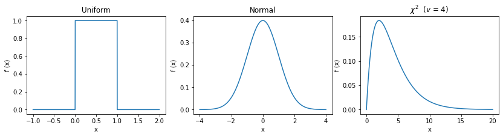

```python
# Define ranges of random variables
x0   = np.linspace(-1, 2, 1001)  # random variable range for the uniform distribution
x1   = np.linspace(-4, 4, 1001)  # random variable range for the normal distribution
x2   = np.linspace(0, 20, 1001)  # random variable range for the chi2 distribution


# Use analytical equations to calculate the probability densities at all x values
pdf0 = stats.uniform.pdf(x0)     # PDF for a uniform random variable
pdf1 = stats.norm.pdf(x1)        # PDF for a normal random variable
pdf2 = stats.chi2.pdf(x2, 4)     # PDF for a chi2 random variable (with degrees of freedom = 4)


# Plot the PDFs
fig,ax = plt.subplots(1, 3, figsize=(14,3))

ax[0].plot(x0, pdf0)
ax[1].plot(x1, pdf1)
ax[2].plot(x2, pdf2)

ax[0].set_title('Uniform')
ax[1].set_title('Normal')
ax[2].set_title('$\chi^2$  ($v$ = 4)')

plt.setp(ax, xlabel='x')
plt.setp(ax, ylabel='f (x)')

plt.show()
```

**Figure 7.1**: Probability density functions for three types of random variables. $x$ = random variable value. $f(x)$ = probability density. $\nu$ = degrees of freedom.

From the PDFs in Fig.7.1, certain probabilities are obvious. For example:

**Uniform**:

- The probablity that $x$ is greater than one is zero: $\hspace{5mm} P(x>1) = 0$
- The probablity that $x$ is greater than 0.5 is 0.5: $\hspace{5mm} P(x>0.5) = 0.5$

**Normal**:

- The probablity that $x$ is greater than zero is 0.5: $\hspace{5mm} P(x>0) = 0.5$
- The probablity that $x$ is less than zero is 0.5: $\hspace{5mm} P(x<0) = 0.5$

How can we use Python to calculate these probabilities **analytically**? The next notebook answers this question.